# NYPD Shooting Incident

anonymous

2024-09-01

#### This is the report of the analyzing NYPD Shooting Incident from 2006 through 2023. It is downloaded from the web site “https://data.gov/”. This dataset contain each recorded represents a shooting incident in NYC. And this database contains information about the location and time of occurrence. In addition, information related to perpetrator and victim are also contained.

```r
data = read.csv("https://data.cityofnewyork.us/api/views/833y-fsy8/rows.csv?accessType=DOWNLOAD")
head(data)
```

```
##   INCIDENT_KEY OCCUR_DATE OCCUR_TIME      BORO LOC_OF_OCCUR_DESC PRECINCT
## 1    244608249 05/05/2022   00:10:00 MANHATTAN            INSIDE       14
## 2    247542571 07/04/2022   22:20:00     BRONX           OUTSIDE       48
## 3     84967535 05/27/2012   19:35:00    QUEENS                        103
## 4    202853370 09/24/2019   21:00:00     BRONX                         42
## 5     27078636 02/25/2007   21:00:00  BROOKLYN                         83
## 6    230311078 07/01/2021   23:07:00 MANHATTAN                         23
##   JURISDICTION_CODE LOC_CLASSFCTN_DESC             LOCATION_DESC
## 1                 0         COMMERCIAL               VIDEO STORE
## 2                 0             STREET                    (null)
## 3                 0
## 4                 0
## 5                 0
## 6                 2                    MULTI DWELL - PUBLIC HOUS
##   STATISTICAL_MURDER_FLAG PERP_AGE_GROUP PERP_SEX PERP_RACE VIC_AGE_GROUP
```

[output cut: 20 more lines]

#### I count the number of incident.

```r
nrow(data)
```

```
## [1] 28562
```

#### At first, I viewed the data. You see there are a lot of numeric data, so I can not know what I can tell at one glance. So I do visualization of this data. There are the data of age, sex, race, and so on. In this time I focused on location and time zone, and analyzed the data. And I will discuss about race data.

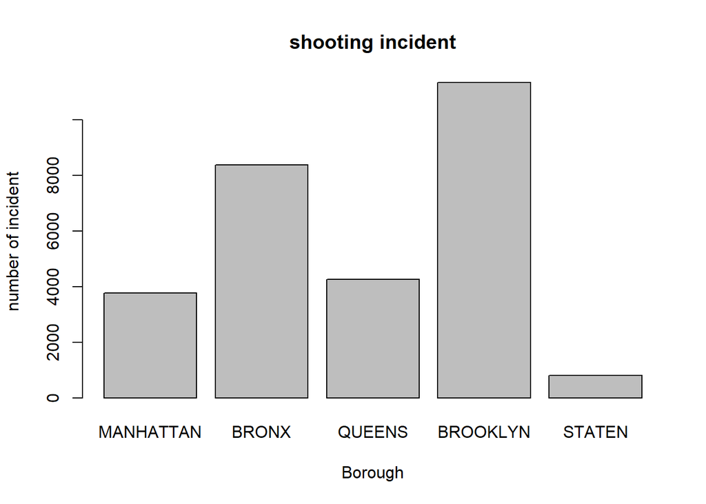

```r
Borough = unique(data$BORO)
s = vector(mode = "double", length = 5)
for (i in 1:5) {
  s[i] = sum(data$BORO == Borough[i])
}
Borough[5] = "STATEN"
barplot(s, names.arg = Borough,
        xlab = "Borough",
        ylab = "number of incident",
        main = "shooting incident")
```

#### First I will talk about the analysis to the location. In the data, I find out five borough. I counted the number of incident at each borough and make graph. This is a bar graph of number of incident at each borough, Manhattan, Bronx, Queens, Brooklyn, Staten Island. We can see Brooklyn is most shooting incident occurred borough. And Staten Island is the least shooting incident occurred borough.

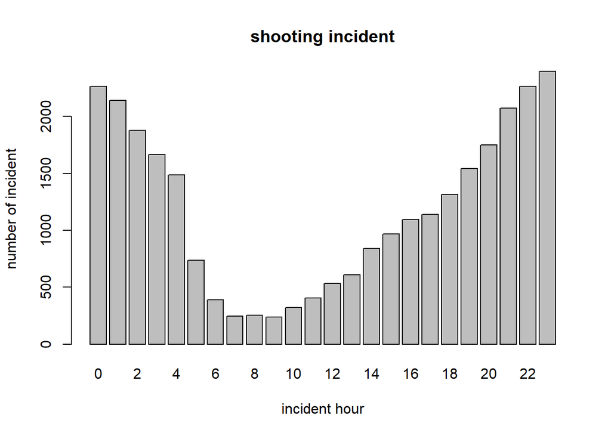

```r
data$hour = substr(data$OCCUR_TIME, 1, 2)
data$hour <- as.integer(data$hour)
hour_data = data.frame(matrix(ncol = 2))
colnames(hour_data) = c("time", "incident")
for(i in 1:24){
  hour_data[i, 1] = i-1
  hour_data[i, 2] = sum(data$hour == i-1)
}
barplot(incident~time, hour_data,
        xlab = "incident hour",
        ylab = "number of incident",
        main = "shooting incident")
```

#### Second, I studied about time zone. I analyzed the number of occurrence changes over time. I counted the number of incident in the each time zone, made the graph. In New York City, we find in the morning time, 7-9 o’clock, shooting incident occurred comparatively small number of incident. Number of occurrences increase gradually time pass and midnight time, 11PM is most time zone.

```r
library(leaflet)
NYmap <- leaflet()
NYmap <- addTiles(NYmap)
NYmap <- addCircleMarkers(NYmap, radius=1, color='black',
                        lng=data$Longitude,
                        lat=data$Latitude)
NYmap
```

[interactive chart not shown]

#### Next, I will discuss about the detail of the location of occurrences. This database contain the data of latitude and longitude. I show the location of incident in the map. I see the positions where incident occurs are not uniformly, uneven distributed. We find there are approximately three densely packed area. And I find there are some area outside of three area where incident occurs frequently. Previously I explain Staten Island is borough that the least shooting incident occurred, but looking into, there is an area incident occurs frequently. At north-east bay. Although, there are too many point in this map, and there is difficulty to know about incident.Although, there are too many point in this map, and there is difficulty to know about incident. Next I analyze ocurrace each time zone.

```r
library(leaflet)
NYmap <- leaflet()
NYmap <- addTiles(NYmap)
NYmap <- addCircleMarkers(NYmap, radius=1, color='blue',
                        lng=data$Longitude[hour_data == 8],
                        lat=data$Latitude[hour_data == 8])
NYmap <- addCircleMarkers(NYmap, radius=1, color='red',
                         lng=data$Longitude[hour_data == 20],
                         lat=data$Latitude[hour_data == 20])
NYmap
```

[interactive chart not shown]

```r
Race = unique(data$PERP_RACE)
Race
```

```
## [1] "BLACK"                          "(null)"
## [3] ""                               "UNKNOWN"
## [5] "WHITE HISPANIC"                 "BLACK HISPANIC"
## [7] "ASIAN / PACIFIC ISLANDER"       "WHITE"
## [9] "AMERICAN INDIAN/ALASKAN NATIVE"
```

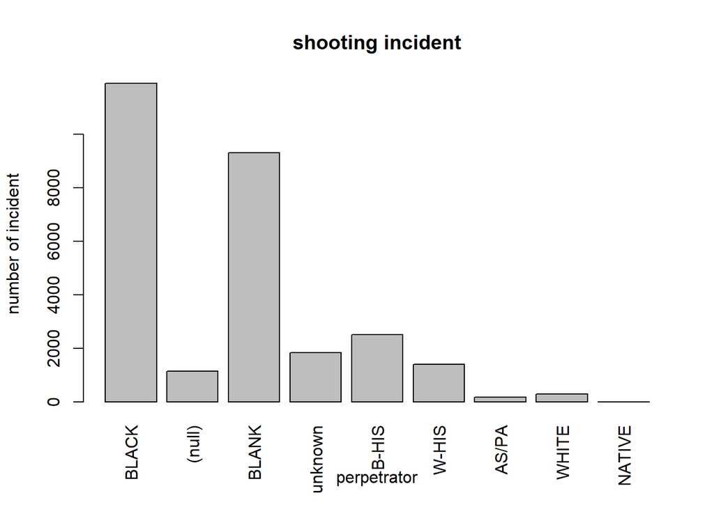

```r
Race_name = Race
Race_name[3] = "BLANK"
Race_name[4] = "unknown"
Race_name[5] = "B-HIS"
Race_name[6] = "W-HIS"
Race_name[7] = "AS/PA"
Race_name[8] = "WHITE"
Race_name[9] = "NATIVE"

race_table = vector(mode = "double", length = 9)
for (i in 1:9) {
  race_table[i] = sum(data$PERP_RACE == Race[i])
}
barplot(race_table,  las=3, names.arg = Race_name,
        xlab = "perpetrator",
        ylab = "number of incident",
        main = "shooting incident")
```